# 証明から学ぶ二項分布

Jikao

2023-02-15

## ベルヌーイ試行

ベルヌーイ試行とは、$p$の確率で成功、$1-p$の確率で失敗する試行を指す。 ベルヌーイ試行の例として、以下のようなものが挙げられる。

・コインを投げて、表が出た時を成功とする試行

・感染者と接触して、病気に感染するかどうか調べる試行

・マックをドカ食いして、気絶するかどうか調べる試行

## 二項分布

確率$p$で成功するベルヌーイ試行を$n$回行うとき、成功する回数を確率変数$X$とみると、$X$は二項分布に従う。

$X=x, 0\leq{}x\leq{}n$となる確率$f(x)$は(0から$n$までの成功回数となる確率は)、反復試行の確率を用いて以下のように表される。

$$f(x)=\dbinom{n}{x}p^x(1-p)^{n-x}$$
$f(x)$の概形は、以下のように表される。

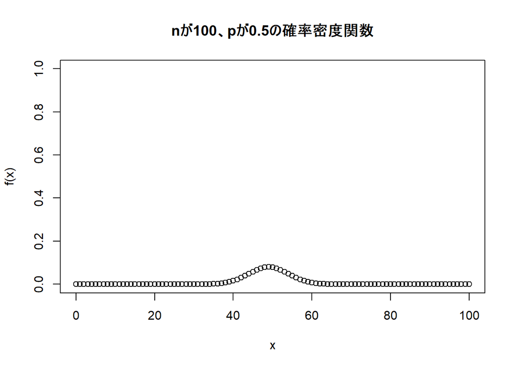

[ここ](https://jikao.shinyapps.io/bin_distr/)をクリックして$n$と$p$を変えてみよう。

## 確率分布であることの証明

確率分布であるには

・$x$がどのような値でも、$f(x)$は0より大きい($\forall{}x\in{}X, f(x)\geq0$)。

・全ての$f(x)$を足すと、合計1になる($\sum_{x\in{}X} = 1$)。

1番目は確率密度関数から自明であるため、2番目を示す。

$$\sum_{x=0}^{n}f(x) = \sum_{x=0}^{n}\dbinom{n}{x}p^x(1-p)^{n-x}$$

ここで、二項定理

$$(a + b)^n = \sum_{x=0}^{n}\dbinom{n}{x}a^kb^{n-x}$$

より確率の和は

$$\begin{eqnarray}
\sum_{x=0}^{n}\dbinom{n}{x}p^x(1-p)^{n-x}　&=& (p + 1-p)^n\\
&=& 1
\end{eqnarray}$$

従って、二項分布の確率密度関数は常に正で、確率の和が1になることから、確率分布であるといえる。

## 二項分布のモーメント母関数

モーメント母関数は

$$M_X(t) = E[e^{tX}]$$

であった。したがって、二項分布のモーメント母関数は

$$\begin{eqnarray}
M_X(t) &=& \sum_{x=0}^{n}e^{tx}\dbinom{n}{x}p^x(1-p)^{n-x}\\
&=& \sum_{x=0}^{n}\dbinom{n}{x}(e^tp)^x(1-p)^{n-x}
\label{eq : mother_func_mid}
\end{eqnarray}$$

ここで、二項定理

$$(a + b)^n = \sum_{x=0}^{n}\dbinom{n}{x}a^kb^{n-x}$$

に関して、$a = e^tp$、$b = 1-p$と置いたものなので、二項定理より以下のように変形でき、これがモーメント母関数となる。

$$M_X(t) = (e^tp + 1 - p)^n$$

## 二項分布の期待値と分散

二項分布の期待値と分散は、以下のように表される。

$$E[X] = np\\
V[X] = np(1-p)$$

## 期待値と分散の証明

モーメント母関数を用いる。

モーメント母関数の0付近での1階微分が期待値$E[X]$となり、2階微分が$E[X^2]$となる。分散$V[X]$が$V[X] = E[X^2]-E[X]^2$と表されることに注意して

となる。

## 二項分布の再生性

ある確率変数$X$が$n, p$を持つ二項分布に従うとき、よく$X\sim{}Bin(n,p)$と表記する。また、確率分布を特徴づける$n, p$をパラメータという。 二項分布には再生性がある。すなわち、確率変数$X$、$Y$がそれぞれ二項分布$Bin(n,p)$、$Bin(m,p)$に従うとき、2つの確率変数の和$X+Y$が二項分布$Bin(n+m,p)$に従う。

$$X\sim{}Bin(n,p),Y\sim{}Bin(m,p)\Leftrightarrow{}X+Y\sim{}Bin(n+m,p)$$